R.PEREZ (June 2024)

# PalmPlanner: Interactive Oil-Palm based Agroforestry Design Tool

- Description
- Installation
- Usage
- Notes

## Description

This Shiny app allows users to represent intercropping designs through different oil palm-based intercropping systems. Users can select various design patterns, adjusting inter row and intra row distances, intercropping distances, and customize colors and names for visualization. Up to three intercrops can be represented within a given oil palm design. The plot shows the density of each crop based on the selected design.

## Installation

To run this app, ensure you have installed R and R studio software (https://posit.co/).

Open the PalmPlanner.Rproj with RStudio, and open the ‘App_design.R’ file in the bottom right window. The code will appear in the RStudio console; click on the “Run App” button in the top right corner of the console window.

The following packages will be automatically installed:

```
shiny
shinythemes
shinycssloaders
tidyverse
plotly
devtools
```

Additionally, the colourpicker package is required and will be installed from GitHub. You may need to launch the application several times to install all the packages.

## Usage

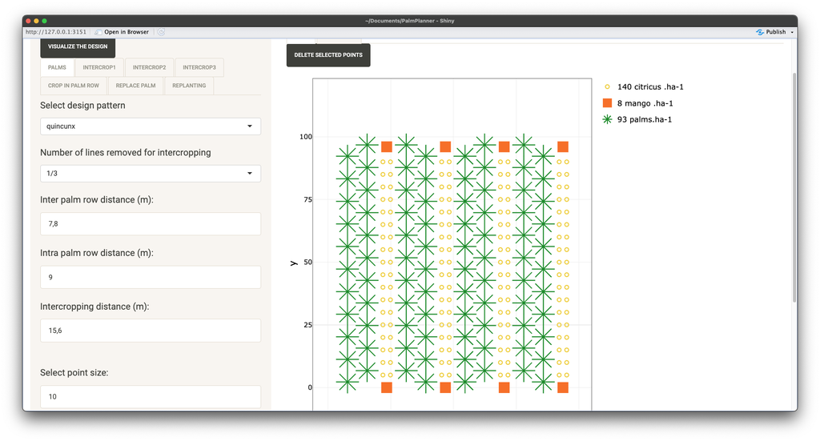

Figure 1: PalmPlanner interface with the selection of input arguments in the left tabs, and the output design in the right panel.

### Oil palm arguments

In the `PALMS` tab, you can modify the following arguments:

`Select design pattern`: type of design, quincunx (tresbolio) or square (cuadrado)

`Number of lines removed for intercropping`: Number of oil palm rows removed from a complete design. `1/ 3` indicates one line removed every three rows. Hence the intercrops will be in located every two rows of oil palms.

`Inter palm row distance (m)`: distance between rows of palms

`Intra palm row distance (m)`: distance within rows of oil palm

`Intercropping distance (m)`: can only be modified when rows of oil palms were removed. Default value is twice the inter row distance

`Select point size` : size of point in the plot

`Select colour` : colour of point in the plot.

### Intercrops arguments

##### Intercrop between rows of palms

In each `INTERCROP` tab, you can modify the following arguments:

`Enter the name of the intercrop`: Enter the name of the intercrop, that will update names in plot legend.

`Select design pattern`: type of design, quincunx (tresbolio) or square (cuadrado)

`Number of lines`: Number of intercrop rows within the intercropping area. Be carefull to adapted the number of lines and the inter row distances to not exceeding the intercrop area.

`Inter row distance (m)`: distance between rows of the intercrop

`Intra row distance (m)`: distance within rows of the intercrop

`y offset (m)`: distance to adapt horizontal alignment between oil palms and intercrops. The value is negative to change intercrops point down in the plot.

`Select point size` : size of point in the plot

`Select colour` : colour of point in the plot.

##### Intercrop in rows of palms

In `CROP IN PALM ROW` tab, crops will be placed on every rows of palms. Only the distance between crop in rows can be adpated

`Intra row distance (m)`: distance within rows of the intercrop

The `REPLACE PALM` tab can be used once palms are deleted in the design. The button `REPLACE DELETED PALMS` will replaced the former deleted palms with the new crop

### Replanting arguments

In the `REPLANTING` tab, you can modify the following arguments:

`visualize old palms`: check box for plotting the old palm positions (default is unchecked box)

`Select design pattern`: type of design, quincunx (tresbolio) or square (cuadrado)

`Inter palm row distance (m)`: distance between rows of palms

`Intra palm row distance (m)`: distance within rows of oil palm

`x offset (m)`: distance to adapt vertical alignment between old oil palms and replanted palms. The value is negative to change intercrops point down in the plot.

`y offset (m)`: distance to adapt horizontal alignment between old oil palms and replanted palms. The value is negative to change intercrops point down in the plot.

`Select point size` : size of point in the plot

### Plot arguments

Additional plot arguments include:

`plot limits (m)`: limits of the plot (x and y axis)

`origin`: set the origin of the plot to the first palm (default)

`Visalize the design`: button to update the design based on the entered arguments.

`DELETED SELECTED POINTS`: button to delete the points selected when clicking on the plot, or selected with the lasso/box tool. The selected points are listed in the `SELECTION` tab. You can remove all the point selected by clicking on the `RESET DATA` button. It is possible that you need to reset twice for deleting all the point. Also you need to unselect the last points saved by double clicking and/or using the lasso on empty region of the plot.If a mis-click occurs while removing or replacing points, only a reset of the app will restore all the points.

## Notes

- The density will be updated when you remove plants.
- You can click on legend to remove one species for the visualization. A double-click allows the visualization of one species
- It is easier to remove points at the end when all the oil palm and intercrops have been designed. You can select only the points of a particular species by double-clicking on the legend.